# Predicting Loan Default using Lending Club Dataset

**Part 2: Modelling**

Load library and dataset

```r
pacman::p_load(dplyr, tidyverse, ggplot2, reshape2, car, caret, ggpubr, DescTools, ROCR,
               xgboost, rpart, rattle, nnet, randomForest, boot)
```

Set working directory and read csv files

```r
setwd("C:/Users/Alvin/Documents/WorkDirectory")

loans_df = read.csv("loansformodelling.csv",stringsAsFactors = TRUE)
tofactor = c("targetloanstatus","creditpolicy","term")
loans_df[,tofactor] = lapply(loans_df[,tofactor], as.factor)
```

**Sampling**

Create our training set using stratified sampling  
Partition dataset into training and test dataset in ratio 70:30

```r
set.seed(123)

inds = createDataPartition(1:nrow(loans_df), p=0.7, list=FALSE,times=1)

loans_dftrain = loans_df[inds,]
nrow(loans_dftrain)/nrow(loans_df)
```

```
## [1] 0.7000353
```

```r
dim(loans_dftrain)
```

```
## [1] 29713    17
```

```r
loans_dftest = loans_df[-inds,]
nrow(loans_dftest)/nrow(loans_df)
```

```
## [1] 0.2999647
```

```r
dim(loans_dftest)
```

```
## [1] 12732    17
```

```r
# use caret to upsample the train dataset
loans_dftrainUP = upSample(loans_dftrain, y = as.factor(loans_dftrain$targetloanstatus), list = TRUE)[[1]]
glimpse(loans_dftrainUP)
```

```
## Observations: 50,432
## Variables: 17
## $ creditpolicy     <fct> 1, 1, 1, 1, 1, 1, 1, 1, 1, 1, 1, 1, 1, 1, 1, ...
## $ loanamnt         <int> 5000, 3000, 7000, 3000, 6500, 12000, 3000, 10...
## $ term             <fct> 36, 60, 60, 36, 60, 36, 36, 36, 36, 36, 36, 6...
## $ intrate          <dbl> 0.1065, 0.1269, 0.1596, 0.1864, 0.1465, 0.126...
## $ emplength        <int> 10, 1, 8, 9, 5, 10, 3, 1, 4, 10, 6, 3, 2, 1, ...
## $ targetloanstatus <fct> 0, 0, 0, 0, 0, 0, 0, 0, 0, 0, 0, 0, 0, 0, 0, ...
## $ dti              <dbl> 27.65, 17.94, 23.51, 5.35, 16.12, 10.78, 12.5...
## $ inqlast6mths     <int> 1, 0, 1, 2, 2, 0, 2, 1, 2, 0, 0, 3, 0, 0, 0, ...
## $ revolutil        <dbl> 0.837, 0.539, 0.856, 0.875, 0.206, 0.671, 0.4...
## $ totalacc         <int> 9, 38, 11, 4, 23, 34, 11, 23, 28, 42, 28, 22,...
## $ delin2years      <fct> N, N, N, N, N, N, N, N, N, N, N, N, N, N, N, ...
## $ homeowner        <fct> N, N, N, N, Y, Y, N, N, N, Y, N, N, Y, N, Y, ...
## $ logannualinc     <dbl> 10.085851, 11.289794, 10.758009, 10.778977, 1...
## $ logrevolbal      <dbl> 9.521422, 10.232216, 9.782844, 9.014569, 8.30...
## $ ratioacc         <dbl> 0.3333333, 0.3947368, 0.6363636, 1.0000000, 0...
## $ verified         <fct> Y, Y, N, Y, N, Y, Y, N, N, N, N, Y, Y, Y, Y, ...
## $ purpose_mod      <fct> credit_card, other, debt_consolidation, car, ...
```

```r
# use caret to downsample the train dataset
loans_dftrainDN = downSample(loans_dftrain, y = as.factor(loans_dftrain$targetloanstatus), list = TRUE)[[1]]
glimpse(loans_dftrainDN)
```

```
## Observations: 8,994
## Variables: 17
## $ creditpolicy     <fct> 1, 1, 1, 1, 1, 1, 1, 1, 1, 1, 1, 1, 1, 1, 1, ...
## $ loanamnt         <int> 16000, 20000, 3000, 2400, 7200, 8000, 6400, 8...
## $ term             <fct> 60, 36, 36, 36, 60, 36, 36, 36, 36, 60, 60, 3...
## $ intrate          <dbl> 0.1074, 0.1349, 0.1000, 0.1649, 0.1528, 0.129...
## $ emplength        <int> 3, 5, 2, 7, 2, 5, 1, 3, 10, 3, 7, 10, 3, 6, 4...
## $ targetloanstatus <fct> 0, 0, 0, 0, 0, 0, 0, 0, 0, 0, 0, 0, 0, 0, 0, ...
## $ dti              <dbl> 7.77, 7.89, 22.99, 2.04, 18.16, 18.32, 15.07,...
## $ inqlast6mths     <int> 0, 1, 0, 0, 1, 0, 0, 0, 1, 0, 2, 0, 3, 0, 2, ...
## $ revolutil        <dbl> 0.404, 0.750, 0.673, 0.764, 0.351, 0.609, 0.2...
## $ totalacc         <int> 48, 35, 28, 5, 17, 9, 12, 27, 20, 22, 15, 15,...
## $ delin2years      <fct> N, N, N, Y, N, N, N, N, N, N, N, N, N, N, N, ...
## $ homeowner        <fct> Y, N, N, N, N, N, N, N, N, Y, Y, Y, Y, N, N, ...
## $ logannualinc     <dbl> 11.082160, 11.849405, 10.341770, 10.348210, 1...
## $ logrevolbal      <dbl> 8.885164, 9.934599, 9.612533, 7.380879, 7.915...
## $ ratioacc         <dbl> 0.3125000, 0.3142857, 0.4285714, 0.8000000, 0...
## $ verified         <fct> Y, Y, N, Y, Y, N, N, N, N, Y, Y, N, Y, Y, N, ...
## $ purpose_mod      <fct> debt_consolidation, credit_card, credit_card,...
```

**Modelling**

1. Logistic Regression

```r
loans_dfglm <- glm(formula = targetloanstatus ~ .,
                   family=binomial,  data=loans_dftrain)
summary(loans_dfglm)
```

```
##
## Call:
## glm(formula = targetloanstatus ~ ., family = binomial, data = loans_dftrain)
##
## Deviance Residuals:
##     Min       1Q   Median       3Q      Max
## -1.7950  -0.6011  -0.4637  -0.3412   2.6711
##
## Coefficients:
##                                 Estimate Std. Error z value Pr(>|z|)
## (Intercept)                    3.483e+00  4.234e-01   8.227  < 2e-16 ***
## creditpolicy1                 -4.013e-01  7.169e-02  -5.598 2.17e-08 ***
## loanamnt                       1.108e-05  2.932e-06   3.779 0.000158 ***
## term60                         5.037e-01  4.357e-02  11.561  < 2e-16 ***
## intrate                        9.564e+00  6.544e-01  14.615  < 2e-16 ***
## emplength                      1.335e-02  5.197e-03   2.569 0.010194 *
## dti                            3.041e-03  2.868e-03   1.060 0.289105
## inqlast6mths                   9.830e-02  1.228e-02   8.002 1.23e-15 ***
## revolutil                      6.038e-01  8.860e-02   6.815 9.40e-12 ***
## totalacc                       5.118e-03  2.076e-03   2.465 0.013718 *
## delin2yearsY                   4.867e-02  5.361e-02   0.908 0.363903
## homeownerY                    -1.167e-02  3.708e-02  -0.315 0.752888
## logannualinc                  -5.606e-01  3.957e-02 -14.168  < 2e-16 ***
## logrevolbal                   -2.841e-02  1.250e-02  -2.273 0.023044 *
## ratioacc                       2.321e-01  1.092e-01   2.125 0.033592 *
## verifiedY                     -4.443e-02  3.749e-02  -1.185 0.235990
## purpose_modcar                -9.348e-01  1.164e-01  -8.034 9.44e-16 ***
## purpose_modcredit_card        -1.003e+00  8.247e-02 -12.167  < 2e-16 ***
## purpose_moddebt_consolidation -7.705e-01  6.732e-02 -11.445  < 2e-16 ***
## purpose_modliving_expenses    -6.914e-01  7.629e-02  -9.063  < 2e-16 ***
## purpose_modluxury             -8.227e-01  9.612e-02  -8.559  < 2e-16 ***
## purpose_modother              -5.541e-01  8.011e-02  -6.917 4.63e-12 ***
## ---
## Signif. codes:  0 '***' 0.001 '**' 0.01 '*' 0.05 '.' 0.1 ' ' 1
##
## (Dispersion parameter for binomial family taken to be 1)
##
##     Null deviance: 25258  on 29712  degrees of freedom
## Residual deviance: 23325  on 29691  degrees of freedom
## AIC: 23369
##
## Number of Fisher Scoring iterations: 5
```

```r
vif(loans_dfglm)
```

```
##                  GVIF Df GVIF^(1/(2*Df))
## creditpolicy 1.635842  1        1.279000
## loanamnt     1.892669  1        1.375743
## term         1.569679  1        1.252868
## intrate      2.030622  1        1.424999
## emplength    1.146704  1        1.070842
## dti          1.293093  1        1.137142
## inqlast6mths 1.657514  1        1.287445
## revolutil    2.215763  1        1.488544
## totalacc     2.118118  1        1.455376
## delin2years  1.092755  1        1.045349
## homeowner    1.218540  1        1.103875
## logannualinc 1.769546  1        1.330243
## logrevolbal  1.956977  1        1.398920
## ratioacc     1.620019  1        1.272800
## verified     1.213254  1        1.101478
## purpose_mod  1.271452  6        1.020215
```

Refine model using step function

```r
loans_dfglm2 = step(loans_dfglm, trace = F)
summary(loans_dfglm2)
```

```
##
## Call:
## glm(formula = targetloanstatus ~ creditpolicy + loanamnt + term +
##     intrate + emplength + inqlast6mths + revolutil + totalacc +
##     logannualinc + logrevolbal + ratioacc + purpose_mod, family = binomial,
##     data = loans_dftrain)
##
## Deviance Residuals:
##     Min       1Q   Median       3Q      Max
## -1.7837  -0.6008  -0.4639  -0.3422   2.6582
##
## Coefficients:
##                                 Estimate Std. Error z value Pr(>|z|)
## (Intercept)                    3.600e+00  4.108e-01   8.763  < 2e-16 ***
## creditpolicy1                 -4.133e-01  7.128e-02  -5.799 6.68e-09 ***
## loanamnt                       1.026e-05  2.860e-06   3.586 0.000335 ***
## term60                         4.938e-01  4.273e-02  11.556  < 2e-16 ***
## intrate                        9.650e+00  6.335e-01  15.233  < 2e-16 ***
## emplength                      1.338e-02  5.132e-03   2.607 0.009126 **
## inqlast6mths                   9.750e-02  1.224e-02   7.969 1.61e-15 ***
## revolutil                      6.090e-01  8.647e-02   7.043 1.88e-12 ***
## totalacc                       5.741e-03  1.962e-03   2.926 0.003431 **
## logannualinc                  -5.718e-01  3.828e-02 -14.937  < 2e-16 ***
## logrevolbal                   -2.684e-02  1.244e-02  -2.158 0.030906 *
## ratioacc                       2.340e-01  1.076e-01   2.175 0.029635 *
## purpose_modcar                -9.346e-01  1.164e-01  -8.033 9.52e-16 ***
## purpose_modcredit_card        -9.970e-01  8.226e-02 -12.121  < 2e-16 ***
## purpose_moddebt_consolidation -7.643e-01  6.708e-02 -11.393  < 2e-16 ***
## purpose_modliving_expenses    -6.909e-01  7.623e-02  -9.063  < 2e-16 ***
## purpose_modluxury             -8.225e-01  9.610e-02  -8.558  < 2e-16 ***
## purpose_modother              -5.500e-01  8.004e-02  -6.872 6.33e-12 ***
## ---
## Signif. codes:  0 '***' 0.001 '**' 0.01 '*' 0.05 '.' 0.1 ' ' 1
##
## (Dispersion parameter for binomial family taken to be 1)
##
##     Null deviance: 25258  on 29712  degrees of freedom
## Residual deviance: 23328  on 29695  degrees of freedom
## AIC: 23364
##
## Number of Fisher Scoring iterations: 5
```

```r
vif(loans_dfglm2)
```

```
##                  GVIF Df GVIF^(1/(2*Df))
## creditpolicy 1.617368  1        1.271758
## loanamnt     1.802149  1        1.342441
## term         1.509689  1        1.228694
## intrate      1.906006  1        1.380582
## emplength    1.119103  1        1.057877
## inqlast6mths 1.645349  1        1.282712
## revolutil    2.111808  1        1.453206
## totalacc     1.897009  1        1.377319
## logannualinc 1.661096  1        1.288835
## logrevolbal  1.932250  1        1.390054
## ratioacc     1.574933  1        1.254963
## purpose_mod  1.240602  6        1.018129
```

```r
# vif < 3 for all variables
```

Check logliklihood

```r
attach(loans_dfglm2)
pchisq(null.deviance - deviance, df.null - df.residual, lower.tail = FALSE)
```

```
## [1] 0
```

```r
anova
```

```
##            Step Df   Deviance Resid. Df Resid. Dev      AIC
## 1               NA         NA     29691   23324.55 23368.55
## 2   - homeowner  1 0.09912382     29692   23324.65 23366.65
## 3 - delin2years  1 0.81485595     29693   23325.47 23365.47
## 4         - dti  1 1.10730030     29694   23326.57 23364.57
## 5    - verified  1 1.35970296     29695   23327.93 23363.93
```

```r
formula # check current formula after step function.
```

```
## targetloanstatus ~ creditpolicy + loanamnt + term + intrate +
##     emplength + inqlast6mths + revolutil + totalacc + logannualinc +
##     logrevolbal + ratioacc + purpose_mod
```

```r
detach(loans_dfglm2)

# Use anova to check remaining variables.
anova(loans_dfglm2, test="Chisq")
```

```
## Analysis of Deviance Table
##
## Model: binomial, link: logit
##
## Response: targetloanstatus
##
## Terms added sequentially (first to last)
##
##
##              Df Deviance Resid. Df Resid. Dev  Pr(>Chi)
## NULL                         29712      25258
## creditpolicy  1   215.38     29711      25043 < 2.2e-16 ***
## loanamnt      1    77.27     29710      24966 < 2.2e-16 ***
## term          1   532.95     29709      24433 < 2.2e-16 ***
## intrate       1   612.52     29708      23820 < 2.2e-16 ***
## emplength     1     0.04     29707      23820   0.84243
## inqlast6mths  1    47.17     29706      23773 6.514e-12 ***
## revolutil     1    17.15     29705      23756 3.456e-05 ***
## totalacc      1    20.59     29704      23735 5.703e-06 ***
## logannualinc  1   229.10     29703      23506 < 2.2e-16 ***
## logrevolbal   1     5.40     29702      23501   0.02015 *
## ratioacc      1     2.56     29701      23498   0.10948
## purpose_mod   6   170.38     29695      23328 < 2.2e-16 ***
## ---
## Signif. codes:  0 '***' 0.001 '**' 0.01 '*' 0.05 '.' 0.1 ' ' 1
```

```r
# Identifies emplength as insignificant variables. Retrain model by removing emplength

loans_dfglm3 <- glm(formula = update.formula(loans_dfglm2, ~ . - emplength),
                    family=binomial,  data=loans_dftrain)
summary(loans_dfglm3)
```

```
##
## Call:
## glm(formula = update.formula(loans_dfglm2, ~. - emplength), family = binomial,
##     data = loans_dftrain)
##
## Deviance Residuals:
##     Min       1Q   Median       3Q      Max
## -1.7907  -0.6006  -0.4636  -0.3431   2.6609
##
## Coefficients:
##                                 Estimate Std. Error z value Pr(>|z|)
## (Intercept)                    3.519e+00  4.091e-01   8.603  < 2e-16 ***
## creditpolicy1                 -4.100e-01  7.126e-02  -5.753 8.75e-09 ***
## loanamnt                       1.051e-05  2.858e-06   3.678 0.000235 ***
## term60                         5.029e-01  4.257e-02  11.813  < 2e-16 ***
## intrate                        9.598e+00  6.331e-01  15.159  < 2e-16 ***
## inqlast6mths                   9.747e-02  1.223e-02   7.968 1.62e-15 ***
## revolutil                      6.093e-01  8.644e-02   7.048 1.81e-12 ***
## totalacc                       5.916e-03  1.960e-03   3.019 0.002536 **
## logannualinc                  -5.589e-01  3.790e-02 -14.748  < 2e-16 ***
## logrevolbal                   -2.575e-02  1.244e-02  -2.070 0.038413 *
## ratioacc                       2.059e-01  1.070e-01   1.925 0.054252 .
## purpose_modcar                -9.297e-01  1.163e-01  -7.991 1.33e-15 ***
## purpose_modcredit_card        -9.940e-01  8.224e-02 -12.087  < 2e-16 ***
## purpose_moddebt_consolidation -7.586e-01  6.703e-02 -11.317  < 2e-16 ***
## purpose_modliving_expenses    -6.858e-01  7.619e-02  -9.002  < 2e-16 ***
## purpose_modluxury             -8.185e-01  9.608e-02  -8.519  < 2e-16 ***
## purpose_modother              -5.451e-01  8.000e-02  -6.814 9.51e-12 ***
## ---
## Signif. codes:  0 '***' 0.001 '**' 0.01 '*' 0.05 '.' 0.1 ' ' 1
##
## (Dispersion parameter for binomial family taken to be 1)
##
##     Null deviance: 25258  on 29712  degrees of freedom
## Residual deviance: 23335  on 29696  degrees of freedom
## AIC: 23369
##
## Number of Fisher Scoring iterations: 5
```

```r
vif(loans_dfglm3)
```

```
##                  GVIF Df GVIF^(1/(2*Df))
## creditpolicy 1.617121  1        1.271661
## loanamnt     1.801092  1        1.342048
## term         1.499388  1        1.224495
## intrate      1.903800  1        1.379783
## inqlast6mths 1.645610  1        1.282813
## revolutil    2.110245  1        1.452668
## totalacc     1.894785  1        1.376512
## logannualinc 1.633716  1        1.278169
## logrevolbal  1.928788  1        1.388808
## ratioacc     1.558742  1        1.248496
## purpose_mod  1.238775  6        1.018004
```

vif < 3 for all variables

Test model on trainset and check accuracy with confusion matrix

```r
pdataglm_train <- predict(loans_dfglm3, newdata = loans_dftrain, type = "response")

confusionMatrix(data = as.factor(as.numeric(pdataglm_train>0.5)), reference = loans_dftrain$targetloanstatus, positive="1")
```

```
## Confusion Matrix and Statistics
##
##           Reference
## Prediction     0     1
##          0 25114  4410
##          1   102    87
##
##                Accuracy : 0.8481
##                  95% CI : (0.844, 0.8522)
##     No Information Rate : 0.8487
##     P-Value [Acc > NIR] : 0.5997
##
##                   Kappa : 0.0252
##
##  Mcnemar's Test P-Value : <2e-16
##
##             Sensitivity : 0.019346
##             Specificity : 0.995955
##          Pos Pred Value : 0.460317
##          Neg Pred Value : 0.850630
##              Prevalence : 0.151348
##          Detection Rate : 0.002928
##    Detection Prevalence : 0.006361
##       Balanced Accuracy : 0.507651
##
##        'Positive' Class : 1
##
```

Accuracy of trainset is 84.8%

Show Variable Importance

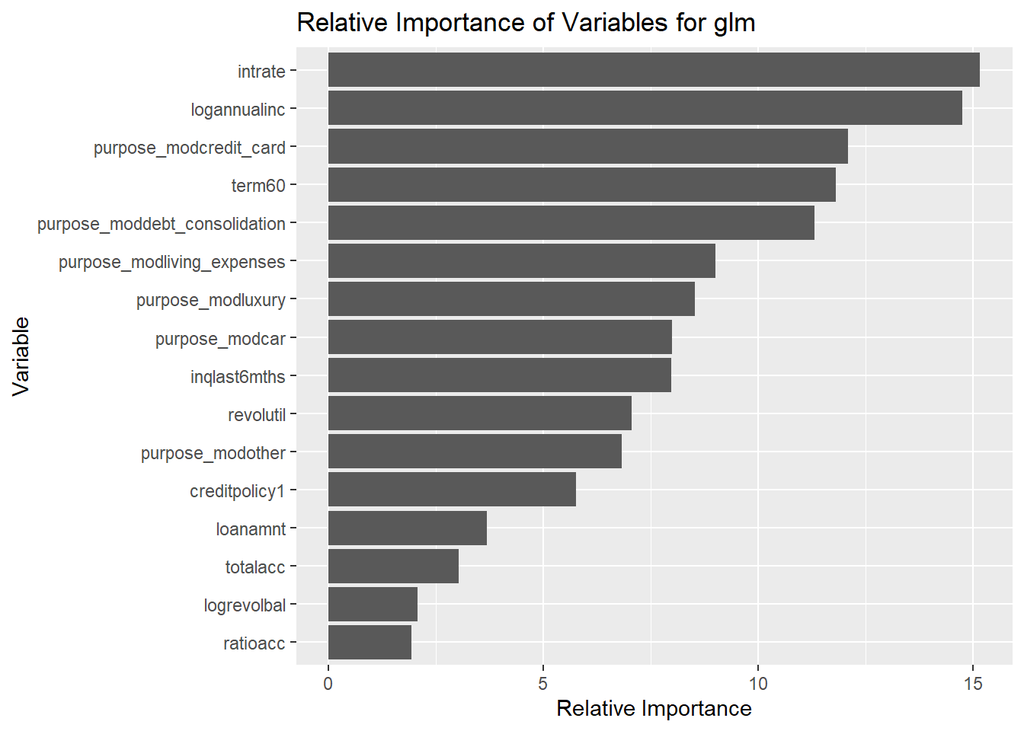

```r
VarImp_glm = as.data.frame(varImp(loans_dfglm3)) %>%
  rownames_to_column("Variable")
VarImp_glm %>%
  ggplot(aes(x = reorder(Variable, Overall), y = Overall))+ geom_col() +
  coord_flip() + labs(title = "Relative Importance of Variables for glm", x = 'Variable', y = 'Relative Importance')
```

Perform prediction on testset and look at confusion matrix.

```r
pdataglm_test <- predict(loans_dfglm3, newdata = loans_dftest, type = "response")

confusionMatrix(data = as.factor(as.numeric(pdataglm_test>0.5)), reference = loans_dftest$targetloanstatus,positive="1")
```

```
## Confusion Matrix and Statistics
##
##           Reference
## Prediction     0     1
##          0 10784  1881
##          1    36    31
##
##                Accuracy : 0.8494
##                  95% CI : (0.8431, 0.8556)
##     No Information Rate : 0.8498
##     P-Value [Acc > NIR] : 0.5554
##
##                   Kappa : 0.0214
##
##  Mcnemar's Test P-Value : <2e-16
##
##             Sensitivity : 0.016213
##             Specificity : 0.996673
##          Pos Pred Value : 0.462687
##          Neg Pred Value : 0.851480
##              Prevalence : 0.150173
##          Detection Rate : 0.002435
##    Detection Prevalence : 0.005262
##       Balanced Accuracy : 0.506443
##
##        'Positive' Class : 1
##
```

Accuracy of test set is 84.9% which is comparable to our training set

2. Bagged logistic regression model

Create function

```r
bagglm = function(model, agg = 10) {
  # takes a glm model input and returns a list of aggregate of models.
  df = model[["model"]]
  formula = formula(model)
  modellist = list()
  for ( i in 1:10) {
    a = sample_n(df, 0.9*nrow(df), replace = TRUE)
    modellist[[length(modellist) + 1]] = glm(formula, family=binomial,  data=a)
  }
  return(modellist)
}

predictbag = function(model, test_df, method = "mean") {
  # method = max or mean
  predictlist = data.frame()[1:nrow(test_df),]
  for (i in model) {
    predictlist = cbind(predictlist,predict(i, newdata = test_df, type = "response"))
  }
  if (method == "max") {
    predictlist$p = apply(predictlist,1,max)
  } else {
    predictlist$p = apply(predictlist,1,mean)
  }
  return(predictlist$p)
}
```

Apply bagging logistic regression Apply model on trainset and check accuracy with confusion matrix

```r
loans_dfglmbag = bagglm(loans_dfglm3, agg = 10)

pdataglmbag_train = predictbag(loans_dfglmbag,loans_dftrain, method = "mean")
confusionMatrix(data = as.factor(as.numeric(pdataglmbag_train>0.5)), reference = loans_dftrain$targetloanstatus,positive="1")
```

```
## Confusion Matrix and Statistics
##
##           Reference
## Prediction     0     1
##          0 25114  4412
##          1   102    85
##
##                Accuracy : 0.8481
##                  95% CI : (0.8439, 0.8521)
##     No Information Rate : 0.8487
##     P-Value [Acc > NIR] : 0.6122
##
##                   Kappa : 0.0245
##
##  Mcnemar's Test P-Value : <2e-16
##
##             Sensitivity : 0.018901
##             Specificity : 0.995955
##          Pos Pred Value : 0.454545
##          Neg Pred Value : 0.850572
##              Prevalence : 0.151348
##          Detection Rate : 0.002861
##    Detection Prevalence : 0.006294
##       Balanced Accuracy : 0.507428
##
##        'Positive' Class : 1
##
```

Perform prediction on testset and look at confusion matrix

```r
pdataglmbag_test = predictbag(loans_dfglmbag,loans_dftest, method = "mean")
confusionMatrix(data = as.factor(as.numeric(pdataglmbag_test>0.5)), reference = loans_dftest$targetloanstatus,positive="1")
```

```
## Confusion Matrix and Statistics
##
##           Reference
## Prediction     0     1
##          0 10786  1880
##          1    34    32
##
##                Accuracy : 0.8497
##                  95% CI : (0.8433, 0.8558)
##     No Information Rate : 0.8498
##     P-Value [Acc > NIR] : 0.5259
##
##                   Kappa : 0.0226
##
##  Mcnemar's Test P-Value : <2e-16
##
##             Sensitivity : 0.016736
##             Specificity : 0.996858
##          Pos Pred Value : 0.484848
##          Neg Pred Value : 0.851571
##              Prevalence : 0.150173
##          Detection Rate : 0.002513
##    Detection Prevalence : 0.005184
##       Balanced Accuracy : 0.506797
##
##        'Positive' Class : 1
##
```

Accuracy on test set is 84.9%

Show variable Importance

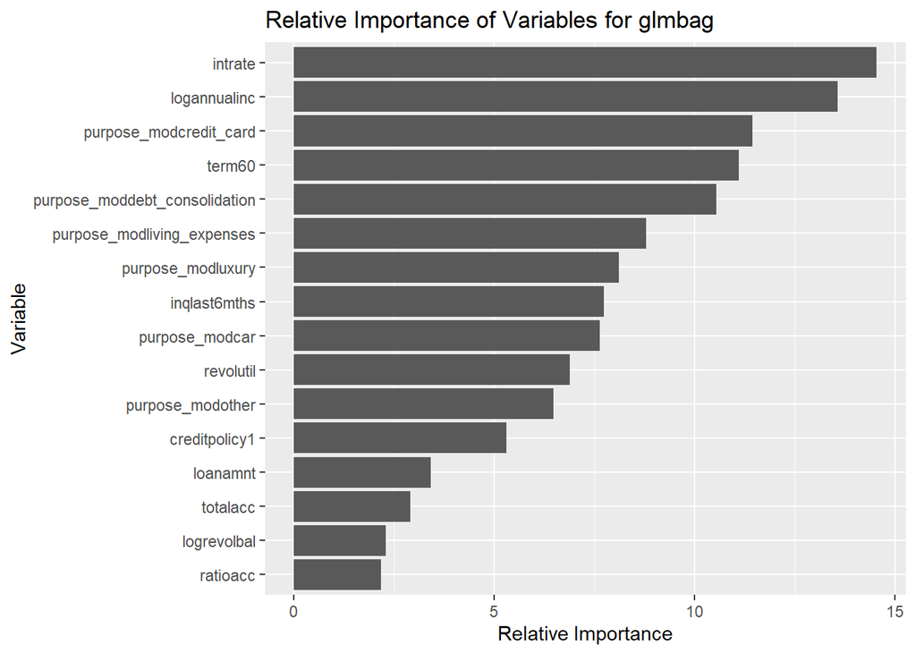

```r
VarImp_glmbag = lapply(loans_dfglmbag,varImp)
VarImp_glmbag = do.call(cbind,VarImp_glmbag)
VarImp_glmbag = apply(VarImp_glmbag,1,mean)
VarImp_glmbag = as.data.frame(VarImp_glmbag) %>%
  `colnames<-`("Overall") %>%
  rownames_to_column("Variable")

VarImp_glmbag %>%
  ggplot(aes(x = reorder(Variable, Overall), y = Overall))+ geom_col() +
  coord_flip() + labs(title = "Relative Importance of Variables for glmbag", x = 'Variable', y = 'Relative Importance')
```

3. Decision Tree

Model using unbalanced dataset

```r
loans_dfrpart <- rpart(formula = targetloanstatus ~ .,
                       data=loans_dftrain,
                       method = "class",
                       parms=list(split="information"),
                       control= rpart.control(minsplit=20,
                                              minbucket=7,
                                              usesurrogate=0,
                                              maxsurrogate=0),
                       model=TRUE)
```

Error encountered rpart not giving good information gain to split the trees on the unbalanced data set  
Try balancing the data before modelling  
Perform modelling on downsampled dataset

```r
loans_dfrpart <- rpart(formula = targetloanstatus ~ .,
                       data=loans_dftrainDN,
                       method = "class",
                       parms=list(split="information"),
                       control= rpart.control(minsplit=20,
                                              minbucket=7,
                                              usesurrogate=0,
                                              maxsurrogate=0),
                       model=TRUE)
```

Generate a textual view of the Decision Tree model  
Show variable importance

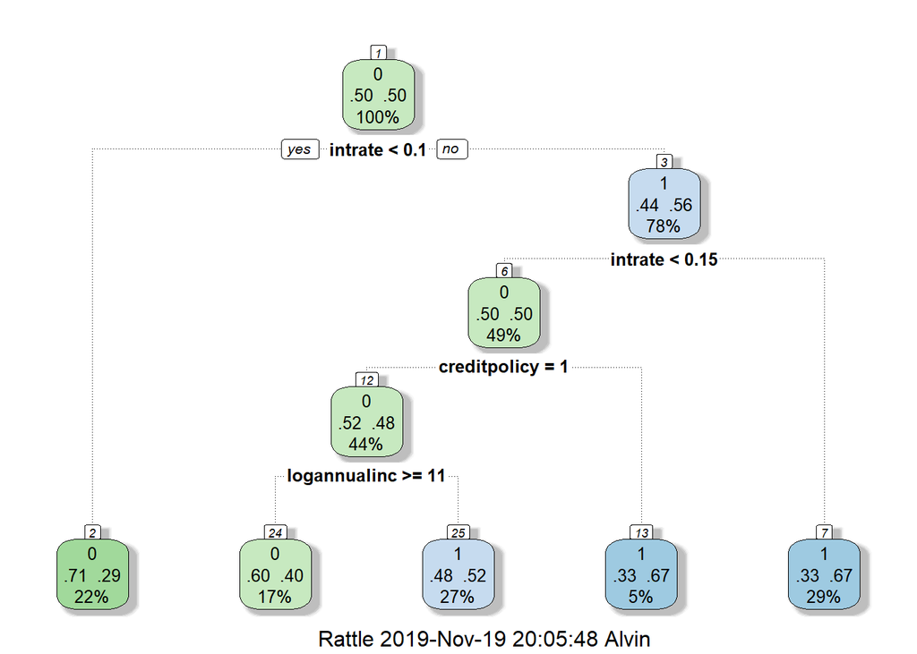

```r
rattle::fancyRpartPlot(loans_dfrpart)
```

```r
summary(loans_dfrpart)
```

```
## Call:
## rpart(formula = targetloanstatus ~ ., data = loans_dftrainDN,
##     method = "class", model = TRUE, parms = list(split = "information"),
##     control = rpart.control(minsplit = 20, minbucket = 7, usesurrogate = 0,
##         maxsurrogate = 0))
##   n= 8994
##
##          CP nsplit rel error    xerror       xstd
## 1 0.1830109      0 1.0000000 1.0246831 0.01054123
## 2 0.0203469      1 0.8169891 0.8247721 0.01038130
## 3 0.0100000      4 0.7507227 0.7765177 0.01027775
##
## Variable importance
##      intrate creditpolicy logannualinc
##           85            7            7
##
## Node number 1: 8994 observations,    complexity param=0.1830109
##   predicted class=0  expected loss=0.5  P(node) =1
##     class counts:  4497  4497
##    probabilities: 0.500 0.500
##   left son=2 (1997 obs) right son=3 (6997 obs)
##   Primary splits:
##       intrate      < 0.09995  to the left,  improve=223.26010, (0 missing)
##       term         splits as  LR,           improve=151.50390, (0 missing)
##       creditpolicy splits as  RL,           improve= 66.65733, (0 missing)
##       revolutil    < 0.7075   to the left,  improve= 64.57783, (0 missing)
##       inqlast6mths < 2.5      to the left,  improve= 53.63103, (0 missing)
##
## Node number 2: 1997 observations
##   predicted class=0  expected loss=0.2939409  P(node) =0.2220369
##     class counts:  1410   587
##    probabilities: 0.706 0.294
##
## Node number 3: 6997 observations,    complexity param=0.0203469
##   predicted class=1  expected loss=0.4411891  P(node) =0.7779631
##     class counts:  3087  3910
##    probabilities: 0.441 0.559
##   left son=6 (4408 obs) right son=7 (2589 obs)
##   Primary splits:
##       intrate      < 0.14985  to the left,  improve=99.00337, (0 missing)
```

[output cut: 33 more lines]

```
##
## Node number 13: 417 observations
##   predicted class=1  expected loss=0.3309353  P(node) =0.04636424
##     class counts:   138   279
##    probabilities: 0.331 0.669
##
## Node number 24: 1564 observations
##   predicted class=0  expected loss=0.4047315  P(node) =0.1738937
##     class counts:   931   633
##    probabilities: 0.595 0.405
##
## Node number 25: 2427 observations
##   predicted class=1  expected loss=0.4763082  P(node) =0.2698466
##     class counts:  1156  1271
##    probabilities: 0.476 0.524
```

```r
loans_dfrpart[["variable.importance"]]
```

```
##      intrate creditpolicy logannualinc
##    322.26343     28.31146     27.09289
```

Test model on trainset and check accuracy with confusion matrix.

```r
pdata_traintree = predict(loans_dfrpart, loans_dftrainDN, type = "class")
confusionMatrix(pdata_traintree, reference = loans_dftrainDN$targetloanstatus,positive="1")
```

```
## Confusion Matrix and Statistics
##
##           Reference
## Prediction    0    1
##          0 2341 1220
##          1 2156 3277
##
##                Accuracy : 0.6246
##                  95% CI : (0.6145, 0.6347)
##     No Information Rate : 0.5
##     P-Value [Acc > NIR] : < 2.2e-16
##
##                   Kappa : 0.2493
##
##  Mcnemar's Test P-Value : < 2.2e-16
##
##             Sensitivity : 0.7287
##             Specificity : 0.5206
##          Pos Pred Value : 0.6032
##          Neg Pred Value : 0.6574
##              Prevalence : 0.5000
##          Detection Rate : 0.3644
##    Detection Prevalence : 0.6041
##       Balanced Accuracy : 0.6246
##
##        'Positive' Class : 1
##
```

Accuracy of trainset is 62.4%

Perform prediction on testset and look at confusion matrix.

```r
pdata_tree = predict(loans_dfrpart, loans_dftest, type = "class")
confusionMatrix(pdata_tree, reference = loans_dftest$targetloanstatus)
```

```
## Confusion Matrix and Statistics
##
##           Reference
## Prediction    0    1
##          0 5639  518
##          1 5181 1394
##
##                Accuracy : 0.5524
##                  95% CI : (0.5437, 0.5611)
##     No Information Rate : 0.8498
##     P-Value [Acc > NIR] : 1
##
##                   Kappa : 0.1249
##
##  Mcnemar's Test P-Value : <2e-16
##
##             Sensitivity : 0.5212
##             Specificity : 0.7291
##          Pos Pred Value : 0.9159
##          Neg Pred Value : 0.2120
##              Prevalence : 0.8498
##          Detection Rate : 0.4429
##    Detection Prevalence : 0.4836
##       Balanced Accuracy : 0.6251
##
##        'Positive' Class : 0
##
```

Show variable importance

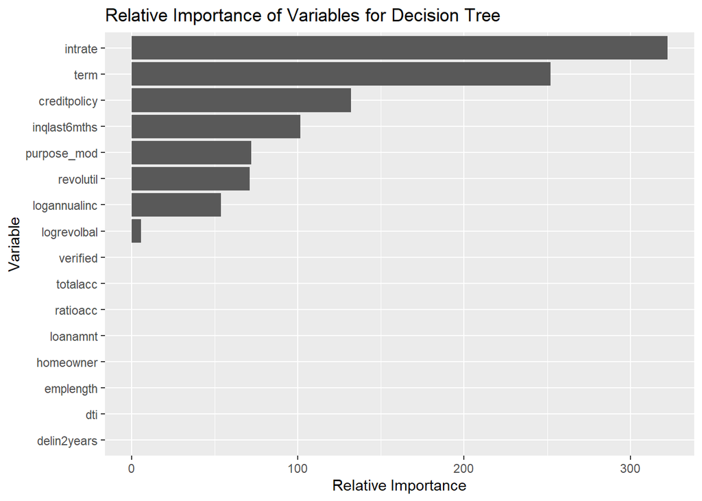

```r
varimp_tree = as.data.frame(varImp(loans_dfrpart)) %>%
  `colnames<-`(c("importance")) %>%
  rownames_to_column("Variable")
varimp_tree %>%
  ggplot(aes(x = reorder(Variable, importance), y = importance))+ geom_col() +
  coord_flip() + labs(title = "Relative Importance of Variables for Decision Tree", x = 'Variable', y = 'Relative Importance')
```

Calculate probabilities for ROC curve

```r
pdata_tree = predict(loans_dfrpart, loans_dftest, type = "prob")
```

4. Random Forest

Build a forest with 1000 trees  
Use sqrt of total number of variables for mtry. Hence try mtry=4

```r
st = Sys.time()
set.seed(123)
rf_dn <- randomForest(targetloanstatus~., loans_dftrainDN,
                      ntree = 1000,
                      mtry = 4,
                      importance = TRUE,
                      cutoff=c(0.5,1-0.5),
                      na.action=na.exclude)
Sys.time()-st #35secs
```

```
## Time difference of 31.60303 secs
```

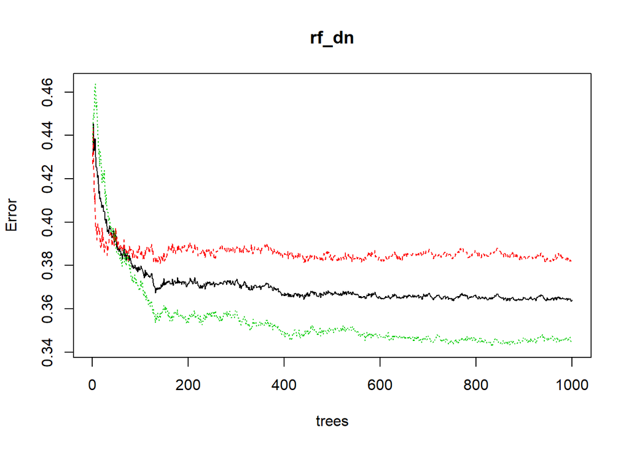

```r
plot(rf_dn)
```

```
## mtry = 4  OOB error = 36.99%
## Searching left ...
## mtry = 8     OOB error = 37.21%
## -0.006011422 0.05
## Searching right ...
## mtry = 2     OOB error = 35.96%
## 0.02795311 0.05
```

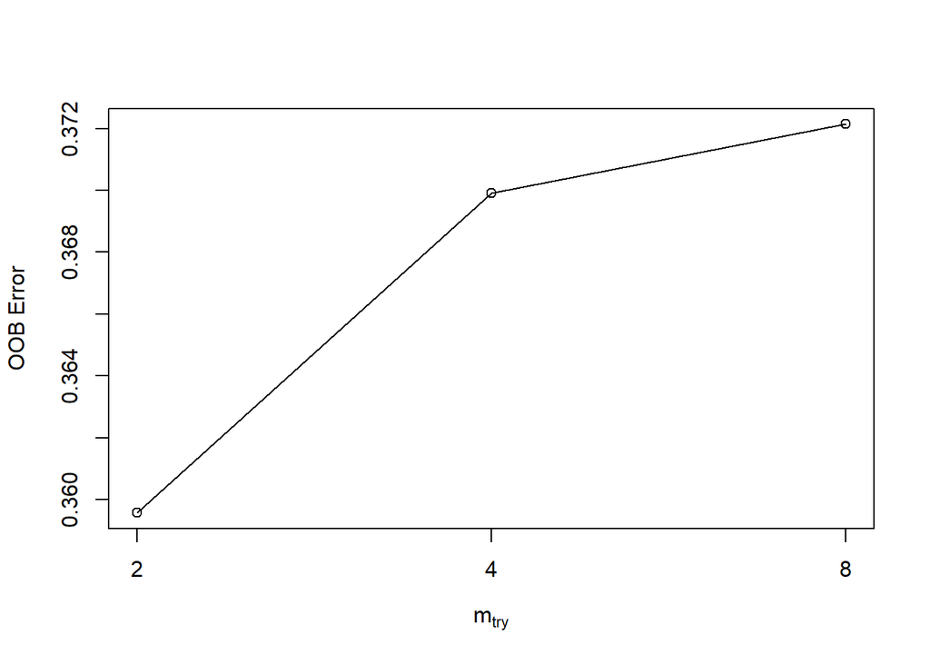

```r
#error stabilies at ntree = 400

st=Sys.time()
t <- tuneRF(loans_dftrainDN[,-6], loans_dftrainDN[,6],
            stepFactor = 0.5,
            plot = TRUE,
            ntreeTry = 400,
            trace = TRUE,
            improve = 0.05)
```

```r
Sys.time()-st
```

```
## Time difference of 15.45457 secs
```

```r
# optimum mtry=2

st = Sys.time()
set.seed(123)
rf_dn <- randomForest(targetloanstatus~., loans_dftrainDN,
                      ntree = 400,
                      mtry = 2,
                      importance = TRUE,
                      cutoff=c(0.5,1-0.5),
                      na.action=na.exclude)
Sys.time()-st
```

```
## Time difference of 12.08643 secs
```

Test model on trainset and check accuracy with confusion matrix

```r
pdatarf_train_cm <- predict(rf_dn, newdata = loans_dftrainDN, type = "response")
confusionMatrix(data = pdatarf_train_cm, reference = loans_dftrainDN$targetloanstatus)
```

```
## Confusion Matrix and Statistics
##
##           Reference
## Prediction    0    1
##          0 4494    0
##          1    3 4497
##
##                Accuracy : 0.9997
##                  95% CI : (0.999, 0.9999)
##     No Information Rate : 0.5
##     P-Value [Acc > NIR] : <2e-16
##
##                   Kappa : 0.9993
##
##  Mcnemar's Test P-Value : 0.2482
##
##             Sensitivity : 0.9993
##             Specificity : 1.0000
##          Pos Pred Value : 1.0000
##          Neg Pred Value : 0.9993
##              Prevalence : 0.5000
##          Detection Rate : 0.4997
##    Detection Prevalence : 0.4997
##       Balanced Accuracy : 0.9997
##
##        'Positive' Class : 0
##
```

Accuracy of training set is 99.9%

Perform prediction on testset and look at confusion matrix.

```r
pdatarf_test_cm <- predict(rf_dn, newdata = loans_dftest, type = "response")
confusionMatrix(data = pdatarf_test_cm, reference = loans_dftest$targetloanstatus)
```

```
## Confusion Matrix and Statistics
##
##           Reference
## Prediction    0    1
##          0 7080  694
##          1 3740 1218
##
##                Accuracy : 0.6517
##                  95% CI : (0.6434, 0.66)
##     No Information Rate : 0.8498
##     P-Value [Acc > NIR] : 1
##
##                   Kappa : 0.176
##
##  Mcnemar's Test P-Value : <2e-16
##
##             Sensitivity : 0.6543
##             Specificity : 0.6370
##          Pos Pred Value : 0.9107
##          Neg Pred Value : 0.2457
##              Prevalence : 0.8498
##          Detection Rate : 0.5561
##    Detection Prevalence : 0.6106
##       Balanced Accuracy : 0.6457
##
##        'Positive' Class : 0
##
```

Calculate probabilities for ROC curve

```r
pdatarf_test= predict(rf_dn, newdata = loans_dftest, type = "prob")
```

Show variable importance

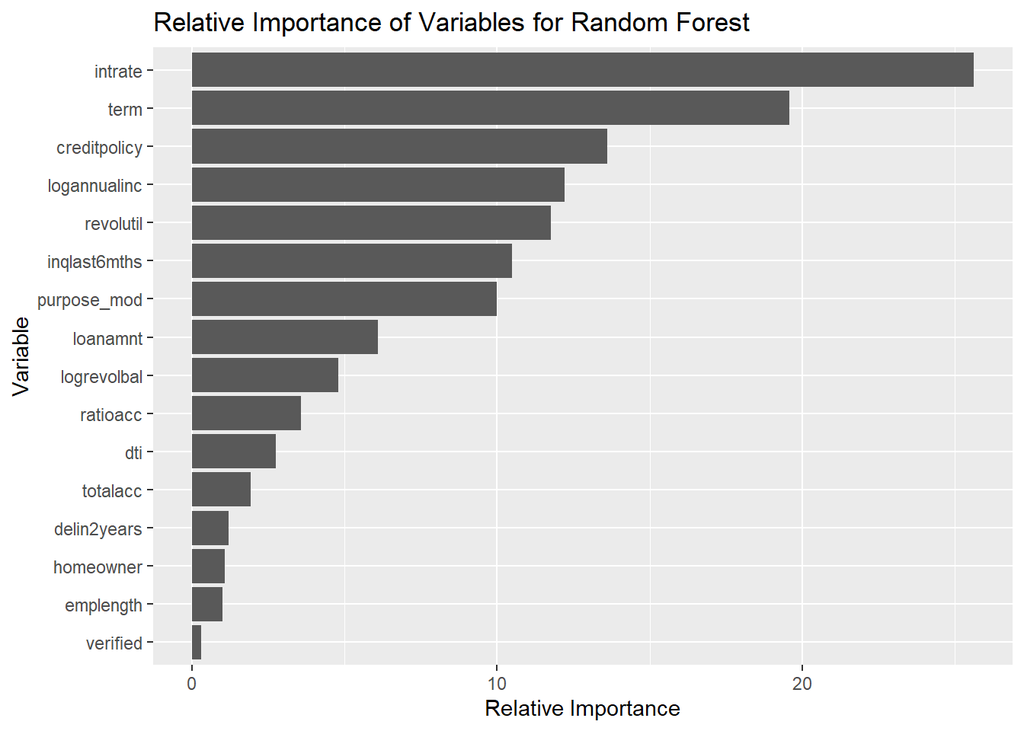

```r
varimp_rf = as.data.frame(varImp(rf_dn)) %>%
  `colnames<-`(c("importance","importance2")) %>%
   select(-importance2) %>%
  rownames_to_column("Variable")
varimp_rf %>%
  ggplot(aes(x = reorder(Variable, importance), y = importance))+ geom_col() +
  coord_flip() + labs(title = "Relative Importance of Variables for Random Forest", x = 'Variable', y = 'Relative Importance')
```

5. Extreme Gradient Boosting Trees

```r
train_x = data.matrix(loans_dftrainDN[,-6])
train_y = loans_dftrainDN[,6]
train_y = ifelse(train_y=="1","1","0")
test_x = data.matrix(loans_dftest[,-6])
test_y = loans_dftest[,6]
test_y = ifelse(test_y=="1","1","0")

xgb_train = xgb.DMatrix(data=train_x, label=train_y)
xgb_test = xgb.DMatrix(data=test_x, label=test_y)

params_tree <- list(booster = "gbtree",
                    eta=0.3, gamma=0, max_depth=6, min_child_weight=1, subsample=1, colsample_bytree=1,
                    objective = "binary:logistic")
```

Xgboost cross validation

```r
set.seed(123)
xgbcv_tree = xgb.cv(data = xgb_train,
                    params = params_tree, nrounds = 100, nfold = 5,
                    showsd = T, stratified = T, print_every_n = 10, early_stop_round = 20, maximize = F)
# Identify iteration with lowest error for xgb tree

which.min((xgbcv_tree[["evaluation_log"]][["train_error_mean"]]))
```

```
## [1] 100
```

```r
which.min((xgbcv_tree[["evaluation_log"]][["test_error_mean"]]))
```

```
## [1] 11
```

```r
set.seed(123)
xgbc_tree <- xgb.train(data = xgb_train,
                       params = params_tree, nfold = 5, nrounds = which.min((xgbcv_tree[["evaluation_log"]][["train_error_mean"]])),
                       verbose = FALSE, eval_metric = 'auc')
```

Show relative importance

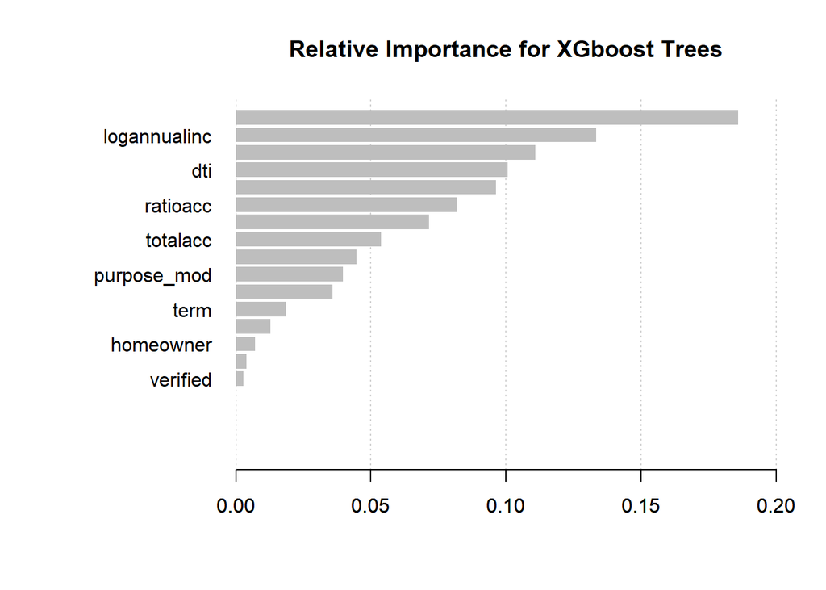

```r
mat_tree = xgb.importance(model=xgbc_tree)
xgb.plot.importance(importance_matrix = mat_tree[1:20],main="Relative Importance for XGboost Trees",cex=1,xlim=c(0,0.2))
```

Test on trainset and check confusion matrix

```r
x2_dn_traintree = predict(xgbc_tree, xgb_train, type="prob")
confusionMatrix(data = as.factor(as.numeric(x2_dn_traintree>0.5)), reference = loans_dftrainDN$targetloanstatus)
```

```
## Confusion Matrix and Statistics
##
##           Reference
## Prediction    0    1
##          0 4080  470
##          1  417 4027
##
##                Accuracy : 0.9014
##                  95% CI : (0.895, 0.9075)
##     No Information Rate : 0.5
##     P-Value [Acc > NIR] : < 2e-16
##
##                   Kappa : 0.8028
##
##  Mcnemar's Test P-Value : 0.08081
##
##             Sensitivity : 0.9073
##             Specificity : 0.8955
##          Pos Pred Value : 0.8967
##          Neg Pred Value : 0.9062
##              Prevalence : 0.5000
##          Detection Rate : 0.4536
##    Detection Prevalence : 0.5059
##       Balanced Accuracy : 0.9014
##
##        'Positive' Class : 0
##
```

Perform prediction on testset and look at confusion matrix

```r
x2_dn_tree = predict(xgbc_tree, xgb_test, type="prob")
confusionMatrix(data = as.factor(as.numeric(x2_dn_tree>0.5)), reference = loans_dftest$targetloanstatus)
```

```
## Confusion Matrix and Statistics
##
##           Reference
## Prediction    0    1
##          0 6739  702
##          1 4081 1210
##
##                Accuracy : 0.6243
##                  95% CI : (0.6159, 0.6328)
##     No Information Rate : 0.8498
##     P-Value [Acc > NIR] : 1
##
##                   Kappa : 0.148
##
##  Mcnemar's Test P-Value : <2e-16
##
##             Sensitivity : 0.6228
##             Specificity : 0.6328
##          Pos Pred Value : 0.9057
##          Neg Pred Value : 0.2287
##              Prevalence : 0.8498
##          Detection Rate : 0.5293
##    Detection Prevalence : 0.5844
##       Balanced Accuracy : 0.6278
##
##        'Positive' Class : 0
##
```

Accuracy = 62.43% for test set

6. Linear Extreme Gradient Boosting

```r
y = loans_dftrain$targetloanstatus
preProcess_range_model <- preProcess(loans_dftrain, method=c('center','scale'))
loans_dftrainBL =  predict(preProcess_range_model, newdata = loans_dftrain)
apply(loans_dftrainBL[, 1:17], 2, FUN=function(x){c('min'=min(x), 'max'=max(x))})
```

```
##     creditpolicy loanamnt        term intrate         emplength
## min "0"          "-0.0030013663" "36" "-0.0006562575" "-0.26613469"
## max "1"          " 3.2208446112" "60" " 3.3444029937" " 1.47130344"
##     targetloanstatus dti             inqlast6mths  revolutil
## min "0"              "-0.0007393463" "-0.05533541" "-1.000970e+00"
## max "1"              " 2.4734386297" "21.17702759" " 9.975515e-01"
##     totalacc       delin2years homeowner logannualinc    logrevolbal
## min "-0.008491317" "N"         "N"       "-0.0004606282" "-1.000578e+00"
## max " 5.873089091" "Y"         "Y"       " 7.4366582435" " 9.999880e-01"
##     ratioacc       verified purpose_mod
## min "-0.001563673" "N"      "business"
## max " 6.741216785" "Y"      "other"
```

```r
loans_dftrainBLDN = downSample(loans_dftrainBL, y = as.factor(loans_dftrainBL$targetloanstatus), list = TRUE)[[1]]

preProcess_range_model_test <- preProcess(loans_dftest, method=c('center','scale'))
loans_dftestBL=  predict(preProcess_range_model_test, newdata = loans_dftest)
apply(loans_dftestBL[, 1:17], 2, FUN=function(x){c('min'=min(x), 'max'=max(x))})
```

```
##     creditpolicy loanamnt       term intrate        emplength
## min "0"          "-0.002332278" "36" "-0.005095620" "-0.26257224"
## max "1"          " 3.233136561" "60" " 3.318759530" " 1.46080763"
##     targetloanstatus dti             inqlast6mths  revolutil
## min "0"              "-1.001177e+00" "-0.04849256" "-0.0009647104"
## max "1"              " 9.997399e-01" "19.64247952" " 2.0026450846"
##     totalacc      delin2years homeowner logannualinc    logrevolbal
## min "-0.02091756" "N"         "N"       "-1.001422e+00" "-1.001484e+00"
## max " 5.55966202" "Y"         "Y"       " 9.979832e-01" " 9.999707e-02"
##     ratioacc       verified purpose_mod
## min "-0.002436862" "N"      "business"
## max " 2.809694767" "Y"      "other"
```

```r
trainBL_x = data.matrix(loans_dftrainBLDN[,-6])
trainBL_y = loans_dftrainBLDN[,6]
trainBL_y = ifelse(trainBL_y=="1","1","0")
testBL_x = data.matrix(loans_dftestBL[,-6])
testBL_y = loans_dftestBL[,6]
testBL_y = ifelse(testBL_y=="1","1","0")

xgb_train = xgb.DMatrix(data=trainBL_x, label=trainBL_y)
xgb_test = xgb.DMatrix(data=testBL_x, label=testBL_y)

params_linear = list(booster = "gblinear",
                     feature_selector = "shuffle", lambda = 1, alpha = 0,
                     objective = "binary:logistic")
```

Xgboost cross validation

```r
set.seed(123)
xgbcv_linear = xgb.cv(data = xgb_train,
                      params = params_linear, nrounds = 100, nfold = 5,
                      showsd = T, stratified = T, print_every_n = 10, early_stop_round = 20, maximize = F)
# identify iteration with lowest error for xgb linear

which.min((xgbcv_linear[["evaluation_log"]][["train_error_mean"]]))
```

```
## [1] 61
```

```r
which.min((xgbcv_linear[["evaluation_log"]][["test_error_mean"]]))
```

```
## [1] 7
```

```r
set.seed(123)
xgbc_linear <- xgb.train(data = xgb_train,
                         params = params_linear, nfold = 5, nrounds = which.min((xgbcv_linear[["evaluation_log"]][["train_error_mean"]])),
                         verbose = FALSE)
```

Test on trainset and check confusion matrix

```r
x2_dn_trainlinear = predict(xgbc_linear, xgb_train, type="prob")
confusionMatrix(data = as.factor(as.numeric(x2_dn_trainlinear>0.5)), reference = loans_dftrainDN$targetloanstatus,positive="1")
```

```
## Confusion Matrix and Statistics
##
##           Reference
## Prediction    0    1
##          0 2840 1702
##          1 1657 2795
##
##                Accuracy : 0.6265
##                  95% CI : (0.6164, 0.6365)
##     No Information Rate : 0.5
##     P-Value [Acc > NIR] : <2e-16
##
##                   Kappa : 0.2531
##
##  Mcnemar's Test P-Value : 0.4477
##
##             Sensitivity : 0.6215
##             Specificity : 0.6315
##          Pos Pred Value : 0.6278
##          Neg Pred Value : 0.6253
##              Prevalence : 0.5000
##          Detection Rate : 0.3108
##    Detection Prevalence : 0.4950
##       Balanced Accuracy : 0.6265
##
##        'Positive' Class : 1
##
```

Perform prediction on testset and look at confusion matrix

```r
x2_dn_linear = predict(xgbc_linear, xgb_test, type="prob")
confusionMatrix(data = as.factor(as.numeric(x2_dn_linear>0.5)), reference = loans_dftest$targetloanstatus,positive="1")
```

```
## Confusion Matrix and Statistics
##
##           Reference
## Prediction    0    1
##          0 6810  690
##          1 4010 1222
##
##                Accuracy : 0.6309
##                  95% CI : (0.6224, 0.6392)
##     No Information Rate : 0.8498
##     P-Value [Acc > NIR] : 1
##
##                   Kappa : 0.1566
##
##  Mcnemar's Test P-Value : <2e-16
##
##             Sensitivity : 0.63912
##             Specificity : 0.62939
##          Pos Pred Value : 0.23356
##          Neg Pred Value : 0.90800
##              Prevalence : 0.15017
##          Detection Rate : 0.09598
##    Detection Prevalence : 0.41093
##       Balanced Accuracy : 0.63426
##
##        'Positive' Class : 1
##
```

Show relative importance

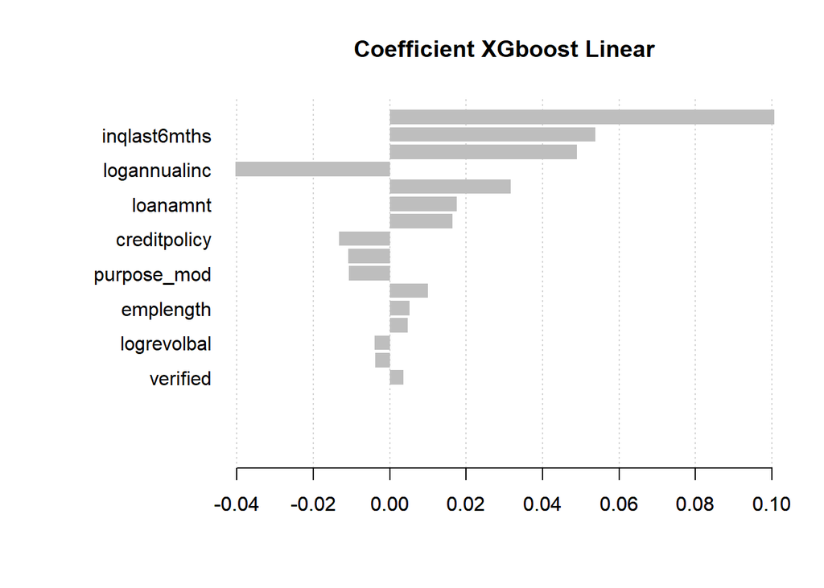

```r
mat_linear = xgb.importance(model=xgbc_linear)
xgb.plot.importance(importance_matrix = mat_linear[1:20],main="Coefficient XGboost Linear",cex=1)
```

7. Neural Network

Normalise numerical variables

```r
y = loans_dftrain$targetloanstatus
preProcess_range_model <- preProcess(loans_dftrain, method='range')
loans_dftrain =  predict(preProcess_range_model, newdata = loans_dftrain)
apply(loans_dftrain[, 1:17], 2, FUN=function(x){c('min'=min(x), 'max'=max(x))})
```

```
##     creditpolicy loanamnt      term intrate      emplength
## min "0"          "0.000000000" "36" "0.00000000" "0.0"
## max "1"          "1.000000000" "60" "1.00000000" "1.0"
##     targetloanstatus dti            inqlast6mths revolutil
## min "0"              "0.0000000000" "0.00000000" "0.0000000000"
## max "1"              "1.0000000000" "1.00000000" "1.0000000000"
##     totalacc     delin2years homeowner logannualinc logrevolbal
## min "0.00000000" "N"         "N"       "0.00000000" "0.00000000"
## max "1.00000000" "Y"         "Y"       "1.00000000" "1.00000000"
##     ratioacc      verified purpose_mod
## min "0.000000000" "N"      "business"
## max "1.000000000" "Y"      "other"
```

One-Hot Encoding for categoral variables

```r
dummies_model = dummyVars(targetloanstatus ~ ., data=loans_dftrain)

# Create the dummy variables using predict. The Y variable (Purchase) will not be present in trainData_mat

loans_dftrain_mat <- predict(dummies_model, newdata = loans_dftrain)
loans_dftrainNN <- data.frame(loans_dftrain_mat)
loans_dftrainNN$targetloanstatus = y
str(loans_dftrainNN)
```

```
## 'data.frame':    29713 obs. of  28 variables:
##  $ creditpolicy.0                : num  0 0 0 0 0 0 0 0 0 0 ...
##  $ creditpolicy.1                : num  1 1 1 1 1 1 1 1 1 1 ...
##  $ loanamnt                      : num  0.1304 0.058 0.0725 0.1884 0.0725 ...
##  $ term.36                       : num  1 0 0 0 1 0 0 1 1 1 ...
##  $ term.60                       : num  0 1 1 1 0 1 1 0 0 0 ...
##  $ intrate                       : num  0.273 0.514 0.379 0.55 0.69 ...
##  $ emplength                     : num  1 0.1 0.1 0.8 0.9 0.4 0.5 1 0.1 0.3 ...
##  $ dti                           : num  0.922 0.0333 0.5982 0.7839 0.1784 ...
##  $ inqlast6mths                  : num  0.0303 0.1515 0 0.0303 0.0606 ...
##  $ revolutil                     : num  0.703 0.079 0.453 0.719 0.735 ...
##  $ totalacc                      : num  0.0899 0.0337 0.4157 0.1124 0.0337 ...
##  $ delin2years.N                 : num  1 1 1 1 1 1 1 1 1 1 ...
##  $ delin2years.Y                 : num  0 0 0 0 0 0 0 0 0 0 ...
##  $ homeowner.N                   : num  1 1 1 1 1 0 0 0 1 1 ...
##  $ homeowner.Y                   : num  0 0 0 0 0 1 1 1 0 0 ...
##  $ logannualinc                  : num  0.328 0.357 0.487 0.417 0.419 ...
##  $ logrevolbal                   : num  0.68 0.531 0.731 0.699 0.644 ...
##  $ ratioacc                      : num  0.164 0.41 0.2 0.343 0.557 ...
##  $ verified.N                    : num  0 0 0 1 0 0 1 0 0 0 ...
##  $ verified.Y                    : num  1 1 1 0 1 1 0 1 1 1 ...
##  $ purpose_mod.business          : num  0 0 0 0 0 1 0 0 0 0 ...
##  $ purpose_mod.car               : num  0 1 0 0 1 0 0 0 0 0 ...
##  $ purpose_mod.credit_card       : num  1 0 0 0 0 0 0 0 0 1 ...
##  $ purpose_mod.debt_consolidation: num  0 0 0 1 0 0 1 1 1 0 ...
##  $ purpose_mod.living_expenses   : num  0 0 0 0 0 0 0 0 0 0 ...
##  $ purpose_mod.luxury            : num  0 0 0 0 0 0 0 0 0 0 ...
##  $ purpose_mod.other             : num  0 0 1 0 0 0 0 0 0 0 ...
##  $ targetloanstatus              : Factor w/ 2 levels "0","1": 1 2 1 1 1 2 1 1 2 1 ...
```

Use caret package to downsample the train dataset

```r
loans_dftrainNNDN = downSample(loans_dftrainNN, y = as.factor(loans_dftrainNN$targetloanstatus), list = TRUE)[[1]]
glimpse(loans_dftrainNNDN)
```

```
## Observations: 8,994
## Variables: 28
## $ creditpolicy.0                 <dbl> 0, 0, 1, 0, 0, 0, 0, 0, 0, 0, 0...
## $ creditpolicy.1                 <dbl> 1, 1, 0, 1, 1, 1, 1, 1, 1, 1, 1...
## $ loanamnt                       <dbl> 0.07246377, 0.11594203, 0.10724...
## $ term.36                        <dbl> 1, 1, 1, 1, 1, 1, 1, 1, 1, 1, 1...
## $ term.60                        <dbl> 0, 0, 0, 0, 0, 0, 0, 0, 0, 0, 0...
## $ intrate                        <dbl> 0.44705269, 0.32811685, 0.50026...
## $ emplength                      <dbl> 0.4, 0.4, 0.6, 0.7, 1.0, 0.8, 0...
## $ dti                            <dbl> 0.19606536, 0.21173725, 0.35645...
## $ inqlast6mths                   <dbl> 0.03030303, 0.06060606, 0.30303...
## $ revolutil                      <dbl> 0.25378151, 0.19495798, 0.08235...
## $ totalacc                       <dbl> 0.13483146, 0.06741573, 0.52808...
## $ delin2years.N                  <dbl> 1, 1, 0, 0, 1, 1, 1, 1, 1, 1, 1...
## $ delin2years.Y                  <dbl> 0, 0, 1, 1, 0, 0, 0, 0, 0, 0, 0...
## $ homeowner.N                    <dbl> 1, 1, 1, 0, 0, 0, 0, 0, 0, 0, 1...
## $ homeowner.Y                    <dbl> 0, 0, 0, 1, 1, 1, 1, 1, 1, 1, 0...
## $ logannualinc                   <dbl> 0.5024599, 0.4194770, 0.4595007...
## $ logrevolbal                    <dbl> 0.6117785, 0.5991521, 0.5724091...
## $ ratioacc                       <dbl> 0.33039091, 0.38875878, 0.15163...
## $ verified.N                     <dbl> 1, 0, 1, 1, 0, 0, 1, 1, 0, 0, 1...
## $ verified.Y                     <dbl> 0, 1, 0, 0, 1, 1, 0, 0, 1, 1, 0...
## $ purpose_mod.business           <dbl> 0, 0, 0, 0, 0, 0, 0, 0, 0, 0, 0...
## $ purpose_mod.car                <dbl> 0, 0, 0, 0, 0, 0, 0, 0, 0, 0, 0...
## $ purpose_mod.credit_card        <dbl> 0, 0, 0, 0, 1, 0, 0, 1, 0, 0, 0...
## $ purpose_mod.debt_consolidation <dbl> 0, 1, 0, 0, 0, 1, 0, 0, 1, 0, 0...
## $ purpose_mod.living_expenses    <dbl> 0, 0, 0, 1, 0, 0, 1, 0, 0, 0, 0...
## $ purpose_mod.luxury             <dbl> 1, 0, 0, 0, 0, 0, 0, 0, 0, 1, 0...
## $ purpose_mod.other              <dbl> 0, 0, 1, 0, 0, 0, 0, 0, 0, 0, 1...
## $ targetloanstatus               <fct> 0, 0, 0, 0, 0, 0, 0, 0, 0, 0, 0...
```

Define neural network parameter

Combine the attributes name for convenience

```r
names <- colnames(loans_dftrainNNDN)
f <- as.formula(paste("targetloanstatus ~", paste(names[!names %in% "targetloanstatus"], collapse = " + ")))
```

Train model

```r
set.seed(123)
st = Sys.time()
nnmodel <- train(f, loans_dftrainNNDN, method='nnet', trace = FALSE,
                 #Grid of tuning parameters to try:
                 tuneGrid=expand.grid(.size=seq(1, 5, by = 1),.decay=c(0,0.001,0.1)))
Sys.time() - st
```

```
## Time difference of 6.889605 mins
```

```r
#a 27-1-1 network with 30 weights

# show neural network result

nnmodel[["finalModel"]]
```

```
## a 27-1-1 network with 30 weights
## inputs: creditpolicy.0 creditpolicy.1 loanamnt term.36 term.60 intrate emplength dti inqlast6mths revolutil totalacc delin2years.N delin2years.Y homeowner.N homeowner.Y logannualinc logrevolbal ratioacc verified.N verified.Y purpose_mod.business purpose_mod.car purpose_mod.credit_card purpose_mod…
## output(s): .outcome
## options were - entropy fitting  decay=0.1
```

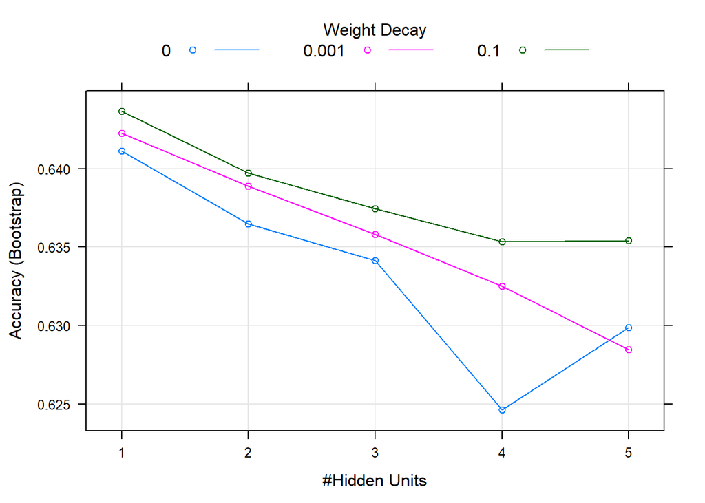

```r
plot(nnmodel)
```

Test model on training set

```r
my_datatrain <- subset(loans_dftrainNNDN, select = -c(targetloanstatus))
predictNN_train_cm <- predict(nnmodel, my_datatrain, type = "raw")

confusionMatrix(data = predictNN_train_cm, reference = loans_dftrainNNDN$targetloanstatus)
```

```
## Confusion Matrix and Statistics
##
##           Reference
## Prediction    0    1
##          0 2670 1355
##          1 1827 3142
##
##                Accuracy : 0.6462
##                  95% CI : (0.6362, 0.6561)
##     No Information Rate : 0.5
##     P-Value [Acc > NIR] : < 2.2e-16
##
##                   Kappa : 0.2924
##
##  Mcnemar's Test P-Value : < 2.2e-16
##
##             Sensitivity : 0.5937
##             Specificity : 0.6987
##          Pos Pred Value : 0.6634
##          Neg Pred Value : 0.6323
##              Prevalence : 0.5000
##          Detection Rate : 0.2969
##    Detection Prevalence : 0.4475
##       Balanced Accuracy : 0.6462
##
##        'Positive' Class : 0
##
```

Use confusion matrix to evaluate model performance on test data.

Data preparation  
Normalise numerical variables  
One-Hot Encoding for categorical variables

```r
z = loans_dftest$targetloanstatus
preProcess_range_model_test <- preProcess(loans_dftest, method='range')
loans_dftest=  predict(preProcess_range_model_test, newdata = loans_dftest)
apply(loans_dftest[, 1:17], 2, FUN=function(x){c('min'=min(x), 'max'=max(x))})
```

```
##     creditpolicy loanamnt      term intrate      emplength
## min "0"          "0.000000000" "36" "0.00000000" "0.0"
## max "1"          "1.000000000" "60" "1.00000000" "1.0"
##     targetloanstatus dti            inqlast6mths revolutil
## min "0"              "0.0000000000" "0.00000"    "0.0000000000"
## max "1"              "1.0000000000" "1.00000"    "1.0000000000"
##     totalacc     delin2years homeowner logannualinc logrevolbal
## min "0.00000000" "N"         "N"       "0.00000000" "0.00000000"
## max "1.00000000" "Y"         "Y"       "1.00000000" "1.00000000"
##     ratioacc     verified purpose_mod
## min "0.00000000" "N"      "business"
## max "1.00000000" "Y"      "other"
```

```r
dummies_model = dummyVars(targetloanstatus ~ ., data=loans_dftest)

# Create the dummy variables using predict.
loans_dftest_mat <- predict(dummies_model, newdata = loans_dftest)
loans_dftestNN <- data.frame(loans_dftest_mat)
loans_dftestNN$targetloanstatus = z
```

Test model on test set

```r
predictNN_test_cm <- predict(nnmodel, loans_dftestNN, type = "raw")
predictNN_test <- predict(nnmodel, loans_dftestNN, type = "prob")

confusionMatrix(data = predictNN_test_cm, reference = loans_dftestNN$targetloanstatus,positive="1")
```

```
## Confusion Matrix and Statistics
##
##           Reference
## Prediction    0    1
##          0 5236  386
##          1 5584 1526
##
##                Accuracy : 0.5311
##                  95% CI : (0.5224, 0.5398)
##     No Information Rate : 0.8498
##     P-Value [Acc > NIR] : 1
##
##                   Kappa : 0.1331
##
##  Mcnemar's Test P-Value : <2e-16
##
##             Sensitivity : 0.7981
##             Specificity : 0.4839
##          Pos Pred Value : 0.2146
##          Neg Pred Value : 0.9313
##              Prevalence : 0.1502
##          Detection Rate : 0.1199
##    Detection Prevalence : 0.5584
##       Balanced Accuracy : 0.6410
##
##        'Positive' Class : 1
##
```

Show relative importance

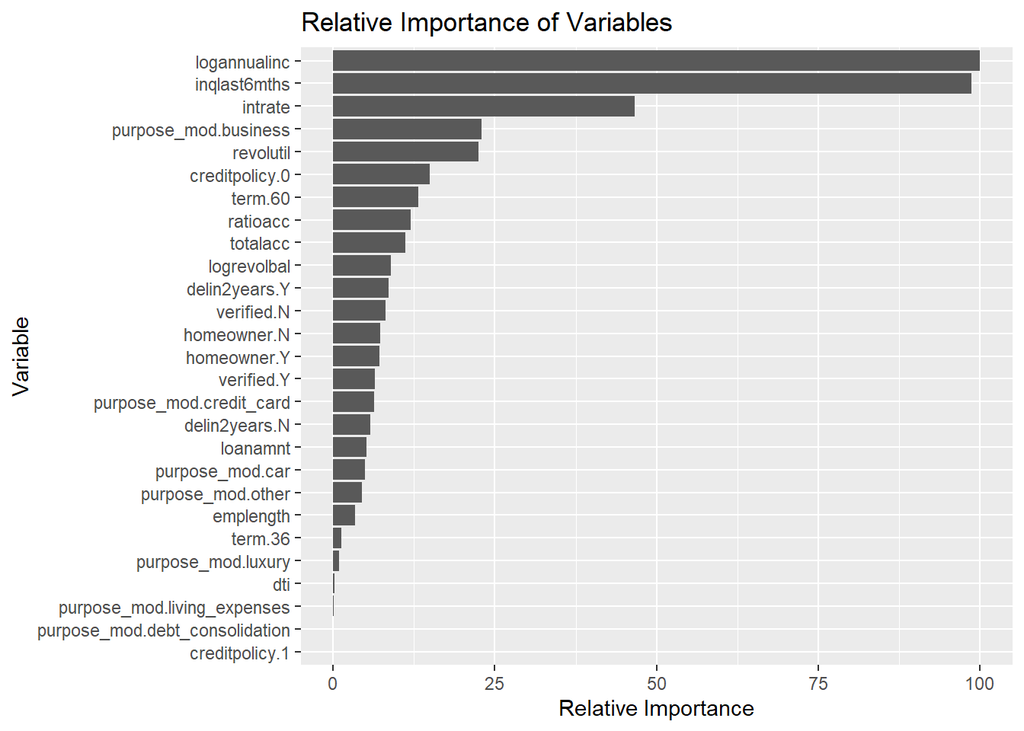

```r
VarImp_nn = varImp(nnmodel)
VarImp_nn %>%
  ggplot(aes(x = names, y = overall))+ geom_bar(stat ='identity') + coord_flip() + labs(title = "Relative Importance of Variables", x = "Variable", y = "Relative Importance")
```

Combine modelling results into a dataframe

```r
foreval = cbind(loans_dftest,
                pvalue_glm = pdataglm_test,
                pvalue_bag = pdataglmbag_test,
                pvalue_tree=pdata_tree[,2],
                pvalue_forest=pdatarf_test[,2],
                pvalue_boosttree=x2_dn_tree,
                pvalue_boostlinear=x2_dn_linear,
                pvalue_NN=predictNN_test[,2])

write.csv(foreval, "foreval.csv", row.names = F)
```